# PML Course Project

David

24 3 2019

### Data Source

The data for this project come from this source: http://web.archive.org/web/20161224072740/http:/groupware.les.inf.puc-rio.br/har. If you use the document you create for this class for any purpose please cite them as they have been very generous in allowing their data to be used for this kind of assignment.

### Load the needed libraries

```r
library(caret)
library(rattle)
```

### Load Data, Data analysis

```r
training <- read.csv("data/pml-training.csv")
testing <- read.csv("data/pml-testing.csv")
str(training)
```

```
## 'data.frame':    19622 obs. of  160 variables:
##  $ X                       : int  1 2 3 4 5 6 7 8 9 10 ...
##  $ user_name               : Factor w/ 6 levels "adelmo","carlitos",..: 2 2 2 2 2 2 2 2 2 2 ...
##  $ raw_timestamp_part_1    : int  1323084231 1323084231 1323084231 1323084232 1323084232 1323084232 1323084232 1323084232 1323084232 1323084232 ...
##  $ raw_timestamp_part_2    : int  788290 808298 820366 120339 196328 304277 368296 440390 484323 484434 ...
##  $ cvtd_timestamp          : Factor w/ 20 levels "02/12/2011 13:32",..: 9 9 9 9 9 9 9 9 9 9 ...
##  $ new_window              : Factor w/ 2 levels "no","yes": 1 1 1 1 1 1 1 1 1 1 ...
##  $ num_window              : int  11 11 11 12 12 12 12 12 12 12 ...
##  $ roll_belt               : num  1.41 1.41 1.42 1.48 1.48 1.45 1.42 1.42 1.43 1.45 ...
##  $ pitch_belt              : num  8.07 8.07 8.07 8.05 8.07 8.06 8.09 8.13 8.16 8.17 ...
##  $ yaw_belt                : num  -94.4 -94.4 -94.4 -94.4 -94.4 -94.4 -94.4 -94.4 -94.4 -94.4 ...
##  $ total_accel_belt        : int  3 3 3 3 3 3 3 3 3 3 ...
##  $ kurtosis_roll_belt      : Factor w/ 397 levels "","-0.016850",..: 1 1 1 1 1 1 1 1 1 1 ...
##  $ kurtosis_picth_belt     : Factor w/ 317 levels "","-0.021887",..: 1 1 1 1 1 1 1 1 1 1 ...
##  $ kurtosis_yaw_belt       : Factor w/ 2 levels "","#DIV/0!": 1 1 1 1 1 1 1 1 1 1 ...
```

[output cut: 86 more lines]

```r
dim(training)
```

```
## [1] 19622   160
```

```r
dim(testing)
```

```
## [1]  20 160
```

```r
unique(training$classe)
```

```
## [1] A B C D E
## Levels: A B C D E
```

### Assignment

The goal of your project is to predict the manner in which they did the exercise. This is the *“classe”* variable in the training set. You may use any of the other variables to predict with. You should create a report describing how you built your model, how you used **cross validation**, what you think the **expected out of sample error** is, and why you made the choices you did. You will also use your prediction model to predict 20 different test cases.

### Data Cleaning

Remove variables with NA’s, remove first variables that deal with the user and timestamps

```r
training <- training[,-c(1:7)]
testing <- testing[,-c(1:7)]
nonNACols <- which(colSums(is.na(training))==0)
training <- training[,nonNACols]
testing <- testing[,nonNACols]
dim(training)
```

```
## [1] 19622    86
```

```r
dim(testing)
```

```
## [1] 20 86
```

Remove the Near Zero Value columns

```r
nzv <- nearZeroVar(training)
training <- training[,-nzv]
dim(training)
```

```
## [1] 19622    53
```

Create the training and validation data sets

```r
inTrain <- createDataPartition(training$classe, p=0.7, list=FALSE)
trainingDS <- training[inTrain,]
validationDS <- training[-inTrain,]
dim(trainingDS)
```

```
## [1] 13737    53
```

```r
dim(validationDS)
```

```
## [1] 5885   53
```

### Training

I decided to start with a random forrest which might already give a good accuracy. Then I will also train a model with a classification tree

In both models we use the **cross-validation technique**. We apply a train control object defining that we use cross validation with 5 folds. Cross validation help limiting overfitting.

#### Train model with method “random forest

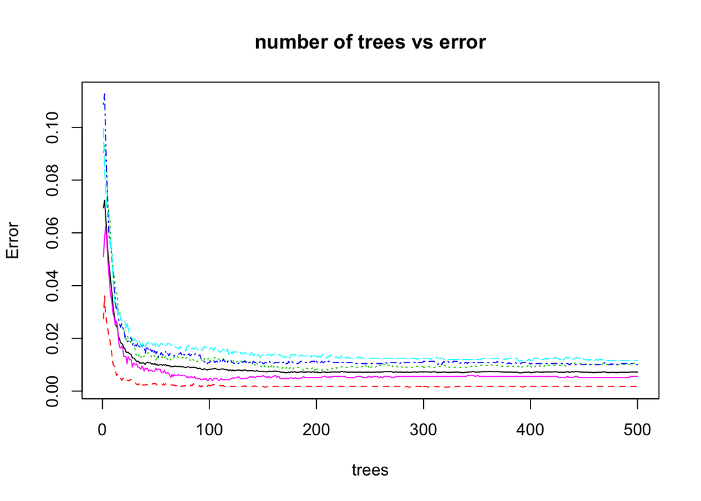

```r
set.seed(2222)
controlRF <- trainControl(method="cv", number=5)
modFitRF <- train(classe ~ ., method="rf", data=trainingDS, verbose=FALSE, trControl=controlRF)
plot(modFitRF$finalModel, main="number of trees vs error")
```

```r
modFitRF$finalModel
```

```
##
## Call:
##  randomForest(x = x, y = y, mtry = param$mtry, verbose = FALSE)
##                Type of random forest: classification
##                      Number of trees: 500
## No. of variables tried at each split: 27
##
##         OOB estimate of  error rate: 0.72%
## Confusion matrix:
##      A    B    C    D    E class.error
## A 3899    4    1    0    2 0.001792115
## B   20 2630    8    0    0 0.010534236
## C    0   14 2372   10    0 0.010016694
## D    0    2   21 2226    3 0.011545293
## E    0    0    5    9 2511 0.005544554
```

Now predict using the validation data set

```r
predRF <- predict(modFitRF, newdata=validationDS)
cmRF <- confusionMatrix(predRF, validationDS$classe)
cmRF$table
```

```
##           Reference
## Prediction    A    B    C    D    E
##          A 1673    8    0    0    0
##          B    0 1125    5    0    1
##          C    1    5 1016   13    2
##          D    0    1    5  951    2
##          E    0    0    0    0 1077
```

```r
cmRF$overall["Accuracy"]
```

```
##  Accuracy
## 0.9926933
```

With *99.2%* we already have a very good accuracy.

#### Train model with method “classificaton tree”

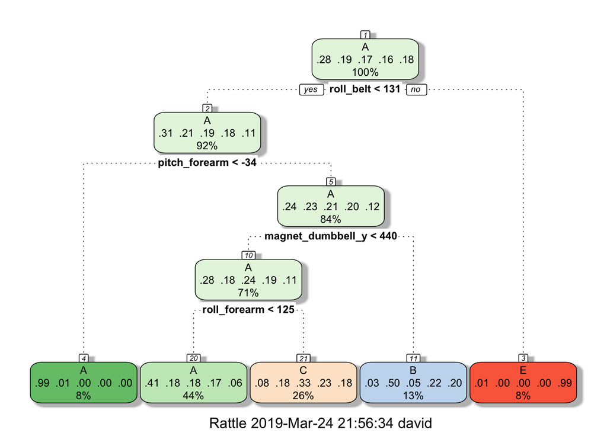

```r
set.seed(3333)
controlRPART <- trainControl(method="cv", number=5)
modFitRPART <- train(classe ~ ., method="rpart", data=trainingDS, trControl=controlRPART)
fancyRpartPlot(modFitRPART$finalModel)
```

```r
modFitRPART$finalModel
```

```
## n= 13737
##
## node), split, n, loss, yval, (yprob)
##       * denotes terminal node
##
##  1) root 13737 9831 A (0.28 0.19 0.17 0.16 0.18)
##    2) roll_belt< 130.5 12596 8699 A (0.31 0.21 0.19 0.18 0.11)
##      4) pitch_forearm< -34 1087    9 A (0.99 0.0083 0 0 0) *
##      5) pitch_forearm>=-34 11509 8690 A (0.24 0.23 0.21 0.2 0.12)
##       10) magnet_dumbbell_y< 439.5 9717 6952 A (0.28 0.18 0.24 0.19 0.11)
##         20) roll_forearm< 124.5 6108 3619 A (0.41 0.18 0.18 0.17 0.063) *
##         21) roll_forearm>=124.5 3609 2411 C (0.076 0.18 0.33 0.23 0.18) *
##       11) magnet_dumbbell_y>=439.5 1792  888 B (0.03 0.5 0.047 0.22 0.2) *
##    3) roll_belt>=130.5 1141    9 E (0.0079 0 0 0 0.99) *
```

Now predict using the validation data set

```r
predRPART <- predict(modFitRPART, newdata=validationDS)
cmRPART <- confusionMatrix(predRPART, validationDS$classe)
cmRPART$table
```

```
##           Reference
## Prediction    A    B    C    D    E
##          A 1516  483  480  436  138
##          B   27  382   23  171  134
##          C  126  274  523  357  311
##          D    0    0    0    0    0
##          E    5    0    0    0  499
```

```r
cmRPART$overall["Accuracy"]
```

```
##  Accuracy
## 0.4961767
```

With only **49.6% the accuracy** the classification tree is pretty bad. Increasing the number of folds makes no change.

So let’s go with the random forrests with an **accuracy of 99.2%** which implies an **out-of-sample-error of 0.8%**

### Testing the model with the test data

No lets predict the classe for the 20 testing data sets provided

```r
predTesting <- predict(modFitRF, newdata=testing)
predTesting
```

```
##  [1] B A B A A E D B A A B C B A E E A B B B
## Levels: A B C D E
```